# A review of social sustainability indicators in agri-food systems using machine learning

Ramdane OS, Doctoral Researcher, UNU-FLORES

August 2021

# Introduction

Using a search string on [Scopus](https://www.scopus.com/search/form.uri?display=basic#basic), I retrieved 128 peer-reviewed scientific papers on social sustainability assessment indicators in agri-food systems. After a throughout reading of the papers to identify and structure social sustainability indicators, I am using Natural Language Processing (NLP) to avoid the subjectivity of traditional content analysis in comparing discourses. This Rmarkdown shows some of the steps involved in the NLP process.

```r
library(readxl)      # Import .xlsx file into R
library(bibliometrix)# Bibliographic analysis in R
library(tidyverse)   # Data manipulation & vizualization
library(tidytext)    # For text mining using tidyverse ecosystem
library(pdftools)    # Import and read pdf files
library(tm)          # For text mining
library(lexicon)     # A collection of lexical hash tables
library(textstem)    # for for Stemming and Lemmatizing Text
library(widyr)       # untidying data into a wide matrix
library(stopwords)   # for stopwords
library(topicmodels) # for topic modeling
library(ggpubr)      # Create beautiful ggplot2-based graphs
library(knitr)       # Produce nice tables outputs
library(knitr)       # Produce nice tables outputs
library(wordcloud2)  # Produce a wordcloud
library(gganimate)   # Produce animated plots
library(ggrepel)     # avoid overlapping text labels in ggplot2
#library(tensorflow) # R interface to TensorFlow
library(keras)       # high-level neural networks API
library(reticulate)  # Reticulate embeds a Python session within R session
library(text2vec)    # efficient framework for NLP in R
library(Rtsne)       # implements Tsne algo in R
library(textdata)    # download and store text data
```

# Text pre-processing steps

## Import papers

In the following code chuck, I import all 128 papers in my R environment.

```r
files <- list.files(path = "Corpora", pattern = "txt$", full.names = TRUE) #Create a vector of pdf file names
#files

#papers <- lapply(files, pdf_text)

#length(papers)
# create a corpus, which is basically a database for text

corp <- Corpus(URISource(files),
               readerControl = list(reader = readPlain))
```

## Text cleaning

To quantitively analyse text data, there is a need to impose a certain structure on it. Tokenisation consisted of breaking texts into minimal meaningful units (words in this case) called tokens. In addition, lemmatisation was used to convert each word to its original form (e.g., do, does, did, done –> do). Other cleaning steps, such as removing stop words (words that do not give us any significant insight from the texts) and removing URLs, numbers, and punctuation, were also performed.

```r
# remove punctuation
corp <- tm_map(corp, content_transformer(removePunctuation))

#remove numbers
corp <- tm_map(corp, content_transformer(removeNumbers))

# transform to lower characters
corp <- tm_map(corp, content_transformer(tolower))

# strip white spaces
corp <- tm_map(corp, content_transformer(stripWhitespace))

# keep the stem of words
#corp <- tm_map(corp, content_transformer(stemDocument), language = "english")

# lemmitization
corp <- tm_map(corp, content_transformer(lemmatize_strings))

#function to remove URLs
removeURL<- function(x) gsub("http[[:alnum:]]*", "", x)

#remove URLs
corp <- tm_map(corp, content_transformer(removeURL))


copy<- corp ## creating a copy to be used later for modelling

# remove stopwords, first attempt
corp <- tm_map(corp, removeWords, stopwords("english"))
```

Here, I am making sure that each tidy corpus has an *id* which is composed of the last name of the first author and the year of publication. In case an author published two papers in the same year *“a”* or *“b”* was added.

```r
# tidy the created corpus


tidy_corp <- tidytext::tidy(corp)

#tidy_corp <-  as.data.frame(tidy_corp)
# select needed columns
tidy_corp <-  tidy_corp %>% select("id", "text")

# remove ".txt" from the id
tidy_corp$id <- gsub(".pdf", "", tidy_corp$id)
tidy_corp$id <- gsub(".txt", "", tidy_corp$id)
#head(tidy_corp)
```

## Joinning the scopus database

After running a search string on Scopus, it is possible to download an Excel file with meta-data (affiliation, country, year, funding, etc.) on all publications that were retrieved. I am joining the Excel file to the tidy corpus of each paper in order to have access to this meta-data.

```r
#import scopus data

scopus <- read_excel("Scopus_1.xlsx")

scopus <- scopus %>% select("id", "Authors", "Year", "Title",  "Source title", "Author Keywords")

#dim(scopus)
#dim(tidy_corp)

tidy_corp <- left_join(tidy_corp, scopus, by = "id")

#View(tidy_corp)

#str(tidy_corp)
```

# Text mining

## Frequent words in the publications

### Manual lemmatisation function

Before looking at the most frequent words used in the publications, I will performe some further text cleaning by writing a function to manually handle some spelling differences between British and American English (e.g., Labor has been changed to Labour), and variations of the same word are counted as one.

```r
paper_tokens <- tidy_corp %>% unnest_tokens("word", text)


manual_lemma <- function(w) {
  # I am using "w" to mean "word"
  #w <- gsub("Labour", "labour", w)
  w <- gsub("labor", "labour", w)
  w <- gsub("agricultural", "agriculture", w)
  w <- gsub("environmental", "environment", w)
  w <- gsub("sustainable", "sustainability", w)
  return(w)
}
# perfom manual lemmatization
paper_tokens$word <- sapply(paper_tokens$word, manual_lemma )

data("stop_words")

paper_tokens_count <-
      paper_tokens %>%
       anti_join(stop_words) %>%
        dplyr::count(word) %>%
         arrange(desc(n))

head(paper_tokens_count, 100)
```

| word | n |
| --- | --- |
| sustainability | 12926 |
| farm | 8491 |
| indicator | 8490 |
| system | 7923 |
| agriculture | 7524 |
| al | 6240 |
| environment | 4652 |
| food | 4244 |
| assessment | 4195 |
| production | 3705 |

[output cut: 90 more lines]

### Wordcloud

The wordcloud below gives a snapshot of the most frequent words.

```r
 library(wordcloud)


# Creating a new dataframe of words I would like to remove manually

custom_stopwords <-
  tribble( ~word,"e", "̀a","al", "b" ,"in", "s","table"  ,"j", "ha", "this",
           "also", "show", "et", "p", "use", "c", "de", "x", "g", "l", "u", "us", "t", "f", "org", "doi", "level", "model")

#Joining the created stop words to the standard stop words

stopwords <- tibble(word = stopwords('en'))

custom_stopwords <- stopwords %>%
 bind_rows(custom_stopwords)

 d <- paper_tokens_count %>%
  anti_join(custom_stopwords)


set.seed(1234)
#wordcloud(words = d$word, freq = d$n, min.freq = 250,
          #max.words=200, random.order=FALSE, rot.per=0.35,
          #colors=brewer.pal(8, "Dark2"))
 wordcloud <-
  d %>%
  rename(freq = n) %>%
  top_n(500) %>%
  wordcloud2(size = .4, minRotation = -pi/2, maxRotation = -pi/2)
wordcloud
```

[interactive chart not shown]

### Plot the top 30 most frequent words

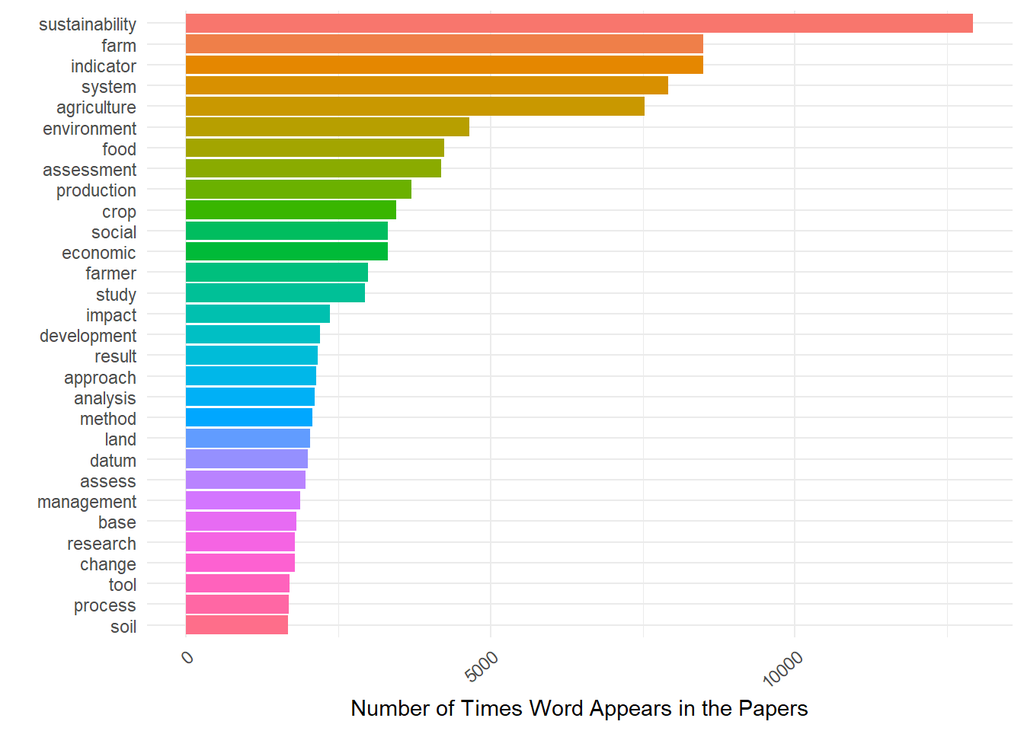

```r
paper_tokens_count <- paper_tokens_count %>%
                      anti_join(custom_stopwords)

#select only top words
top_30<-paper_tokens_count[1:30,]


#create factor variable to sort by frequency
top_30$word <- factor(top_30$word, levels = top_30$word[order(top_30$n,decreasing=TRUE)])

# plot top words
library(ggplot2)
ggplot(top_30, aes(x=reorder(word, n), y=n, fill=word))+
  geom_bar(stat="identity")+
  theme_minimal()+
  theme(axis.text.x = element_text(angle = 40, hjust = 1))+
  ylab("Number of Times Word Appears in the Papers")+
  xlab("")+
  coord_flip() +
  guides(fill=FALSE)
```

### Frenquent words before and after the SDGs

The tidy corpora was divided in two periods using the introduction of the SDGs as a reference. The SDGs’ introduction is considered a crucial event with potential shocks on the formulation of indicators, inspired by the literature on event studies see [1].

```r
#group the years into before and after 2015 (SDGs)
paper_tokens_period <- paper_tokens %>%
  anti_join(custom_stopwords) %>%
  mutate(period = ifelse(Year < 2015, "Before SDGs", "After SDGs")) %>%
   group_by(period)

#frequent words by period

paper_tokens_period <-
      paper_tokens_period %>%
       anti_join(stop_words) %>%
        dplyr::count(word, period) %>%
         arrange(desc(n))

paper_tokens_period %>% filter(period == "Before SDGs")
```

| period | word | n |
| --- | --- | --- |
| Before SDGs | sustainability | 3275 |
| Before SDGs | farm | 2884 |
| Before SDGs | indicator | 2398 |
| Before SDGs | agriculture | 2250 |
| Before SDGs | system | 2078 |
| Before SDGs | environment | 1339 |
| Before SDGs | crop | 1244 |
| Before SDGs | assessment | 1053 |
| Before SDGs | economic | 941 |
| Before SDGs | social | 936 |

[output cut: 9990 more lines]

```r
paper_tokens_period %>% filter(period == "After SDGs")
```

| period | word | n |
| --- | --- | --- |
| After SDGs | sustainability | 9651 |
| After SDGs | indicator | 6092 |
| After SDGs | system | 5845 |
| After SDGs | farm | 5607 |
| After SDGs | agriculture | 5274 |
| After SDGs | food | 3562 |
| After SDGs | environment | 3313 |
| After SDGs | assessment | 3142 |
| After SDGs | production | 2875 |
| After SDGs | social | 2376 |

[output cut: 9990 more lines]

```r
#paper_tokens_period %>% filter(word == "sustainability" | word == "agriculture")
```

```r
 words_bef_after <- paper_tokens_period %>%
                     filter(period %in% c("Before SDGs", "After SDGs")) %>%
                     filter(word %in% c("sustainability", "farm", "indicator",
                                        "system", "agriculture","food",
                                        "environment", "assessment", "approach", "water",
                                        "production", "social", "economic",
                                        "study", "crop",
                                        "impact", "development",
                                        "analysis", "land", "management"))


words_bef_after <- words_bef_after %>%
                   mutate(period = factor(period, levels = c("Before SDGs",
                                          "After SDGs")) )


levels(words_bef_after$period)
```

```
## [1] "Before SDGs" "After SDGs"
```

```r
words_bef_after
```

| period | word | n |
| --- | --- | --- |
| After SDGs | sustainability | 9651 |
| After SDGs | indicator | 6092 |
| After SDGs | system | 5845 |
| After SDGs | farm | 5607 |
| After SDGs | agriculture | 5274 |
| After SDGs | food | 3562 |
| After SDGs | environment | 3313 |
| Before SDGs | sustainability | 3275 |
| After SDGs | assessment | 3142 |
| Before SDGs | farm | 2884 |

[output cut: 30 more lines]

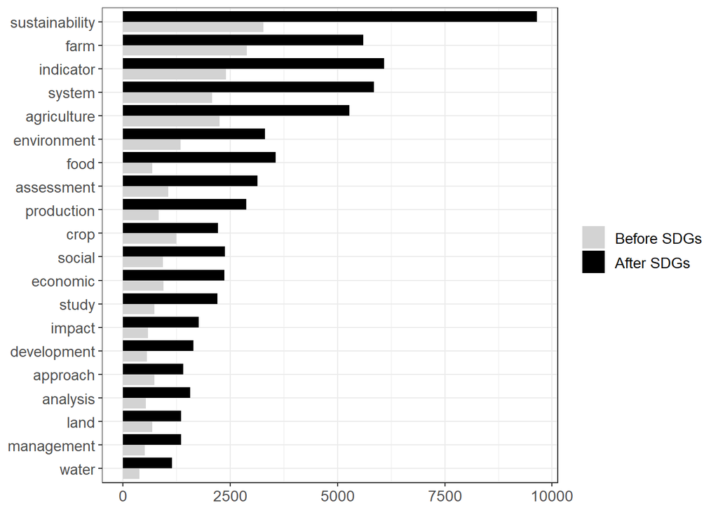

```r
gg_bef_after <-
  words_bef_after %>%
  ggplot(aes(x = reorder(word, n), y = n)) +
  geom_col(aes(fill = period), position = "dodge") +
  scale_fill_manual(values=c('lightgray','black')) +
  theme_bw() +
  theme(text = element_text(size=13),
        legend.title = element_blank(),
        plot.title = element_text(hjust = 0.5)) +
  coord_flip() +
  labs(title = NULL, x = NULL, y = NULL)
  #labs(title = "Before SDGs", x = NULL, y = NULL)
gg_bef_after
```

```r
#ggsave("gg_bef_after.jpeg")
```

### How has the usage of the word social evolved over time?

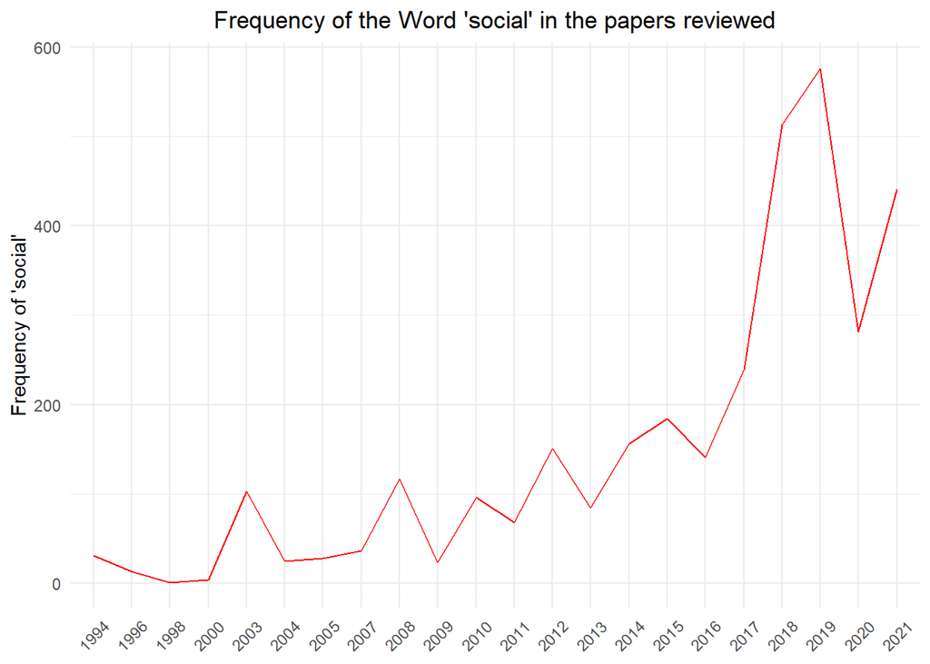

We notice a stark increase of the word “social” in the literature after the introduction of the SDGs.

### Social Sustainability Indicator-related keywords (SSI keywords)

Based on the reading done during the content analysis, I could identify 15 keywords that are mainly mentioned in the context of social sustainability indicators in the papers. I will refer to them as SSI keywords in the remainder of this script and analyse them using different NLP methods.

```r
s_indicators <- c("health", "food", "land", "water", "labour", "participation", "education", "equality", "gender", "inequality", "decent", "conflict", "employment", "sustainability", "agriculture")

paper_tokens_count %>% filter (word %in% s_indicators)
```

| word | n |
| --- | --- |
| sustainability | 12926 |
| agriculture | 7524 |
| food | 4244 |
| land | 2038 |
| water | 1529 |
| labour | 904 |
| health | 686 |
| education | 376 |
| participation | 358 |
| gender | 295 |

[output cut: 5 more lines]

For efficiency, eight of the SSI keywords appearing more than hundred times in total were filtered and further examined.

```r
paper_social_words <-
      paper_tokens %>%
       anti_join(stop_words) %>%
        dplyr::count(word, Year) %>%
         arrange(desc(n)) %>%
          filter(word %in% c("social", "labour", "food", "health", "water", "participation", "land", "education", "gender"))

#"cohesion", "education", "inequality", "equality"

#head(paper_social_words)

# Transform data to add labels

data_label <- paper_social_words %>%
  group_by(word) %>%
  filter(n == max(n))

data_label$label <- data_label$word

data_label <- data_label[1:9,]

data_label
```

| word | Year | n | label |
| --- | --- | --- | --- |
| food | 2019 | 1378 | food |
| social | 2019 | 576 | social |
| land | 2019 | 327 | land |
| water | 2019 | 294 | water |
| labour | 2021 | 176 | labour |
| gender | 2018 | 164 | gender |
| health | 2019 | 138 | health |
| participation | 2019 | 90 | participation |
| education | 2018 | 58 | education |

```r
#data_label$label[which(data_label$word == max(data_label$n))] <- data_label$word[which(data_label$word == max(data_label$n))]

#data_label <- data_label %>%
              #filter(n > 70)



str(paper_social_words)
```

```
## tibble [174 × 3] (S3: tbl_df/tbl/data.frame)
##  $ word: Named chr [1:174] "food" "food" "social" "social" ...
##   ..- attr(*, "names")= chr [1:174] "food" "food" "social" "social" ...
##  $ Year: chr [1:174] "2019" "2018" "2019" "2018" ...
##  $ n   : int [1:174] 1378 922 576 513 473 441 327 307 294 282 ...
```

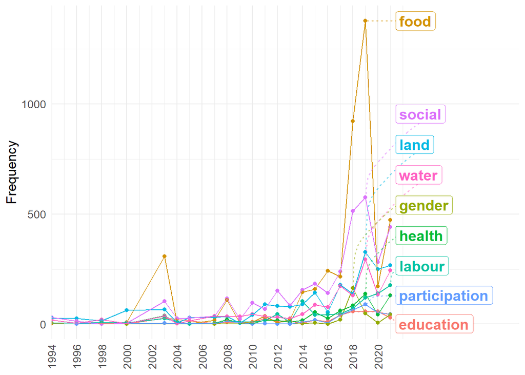

```r
#social_count_plot <-
plot_anim <- ggplot(paper_social_words,
                    aes(x= as.integer(Year), y=n, group = word, col = word))+
  geom_point() +
  geom_line()+
  theme_minimal()+
  theme(legend.position = "none",
          plot.title=element_text(hjust=0.5),
          text = element_text(size=13),
          axis.text.x =
            element_text(angle = 90, vjust = 0.5, hjust=0.5)) +
  labs(title = NULL, x = NULL, y = "Frequency") +
  geom_label_repel(data = data_label, aes(label = label),
                   family = "Lato",
                   fontface = "bold",
                   size = 5,
                   direction = "y",
                   xlim = c(2021, NA),
                   hjust = 0.45,
                   segment.size = .7,
                   segment.alpha = .5,
                   segment.linetype = "dotted",
                   box.padding = .4,
                   segment.curvature = 0.2,
                   segment.ncp = 3,
                   segment.angle = 20) +
  scale_x_continuous(expand = expansion(mult = c(0, 0.38)),
                     limits = c(1994, 2021),
                     breaks = seq(1994, 2021, by = 2)) #+

  #transition_reveal(as.integer(Year))

  #animate(plot_anim, height=420, width=800,fps=30, duration=10, res=100, rewind = FALSE, renderer = gifski_renderer(loop = FALSE))

plot_anim
```

```r
 #Save at gif:
#anim_save("social_count_plot_1.gif")

#ggsave('plot_anim.png', width=15, height=5)
#ggsave("WordSocial.jpeg")
```

# Word embeddings

“Word embeddings are a way to represent text data as vectors of numbers based on a huge corpus of text, capturing semantic meaning from words’ context” [2, p. 106]. Word vectors were built based on a famous quote by JR Firth: “You shall know a word by the company it keeps” [3, p. 11].

## The GloVe Algo

There are two prominent algorithms for word embeddings, word2vec and GloVe. The GloVe algorithm for Global Vectors was used as it takes both global statistics of a word and local statistics in a corpus to come up with word vectors. This application generally follows the implementation by [Dmitriy Selivanov](https://cran.r-project.org/web/packages/text2vec/vignettes/glove.html), which you’ll definitely want to spend some time with. You can read more about the algorithm [here](https://nlp.stanford.edu/projects/glove/).

The algorithm uses the co-occurrence matrix to derive a semantic relationship between words. Considering a corpus of *V* words, the co-occurrence matrix *X* will be a *V x V* matrix, where the *i-th* row and the *j-th* column of *X*, $X_{i,j}$, indicate how often word *i* has co-occurred with word *j* (Pennington et al., 2014). Once the word vectors are known, a widely used measure to compare them is the cosine similarity which is the cosine of the angle between word vectors in a given space and ranges from −1 (most distant) to 1 (closest) [4]. For two word vectors *wx,wy*, the cosine similarity is computed using the following formula:

$$cos(wx, wy) = \frac{wx\cdot\
wy}{||wx||\cdot\ ||wy||}$$

```r
#create period variable in tidy_copy

tidy_copy <- tidy_copy %>%
              mutate(period = ifelse(Year < 2015, "Before SDGs", "After SDGs"))

#split tidy_copy dataframe into two by filtering by period

before <- tidy_copy %>%
           filter(period == "Before SDGs")

head(before)
```

| id | text | Authors | Year | Title | Source title | Author Keywords | period |
| --- | --- | --- | --- | --- | --- | --- | --- |
| 1994_Izac | ecological\neconomics\nelsevier ecological economics \n\n\n\n\n agricultural sustainability measurement smallscale\nfarm subsaharan africa\namn izac mj swift b\nainternational centre research agrofore… | Izac A.-M.N., Swift M.J. | 1994 | On agricultural sustainability and its measurement in small-scale farming in sub-Saharan Africa | Ecological Economics | Agriculture; Indicators; Sub-Saharan Africa; Sustainability | Before SDGs |
| 1996_Ikerd | american journal alternative agriculture\n\n\nadditional service american journal alternative agriculture\n\n\nemail alert click \nsubscription click \ncommercial reprint click \nterm use click \n\n\n… | Ikerd J., Devino G., Traiyongwanich S. | 1996 | Evaluating the sustainability of alternative farming systems: A case study | American Journal of Alternative Agriculture | Conservation Reserve Program; Intensive grazing; Local economic impacts; Missouri; Sustainable agriculture | Before SDGs |
| 1998_Hanegraaf | biomass bioenergy vol pp b\nelsevier science ltd right reserve\nprint great britain\npii s see front matter\n\n\n\n\nassess ecological economic\nsustainability energy crop\nmarjoleine c hanegraaf edo … | Hanegraaf M.C., Biewinga E.E., Van Der Bijl G. | 1998 | Assessing the ecological and economic sustainability of energy crops | Biomass and Bioenergy | Biomass; Chain analysis; Ecology; Economy; Energy crops; Environment; Greenhouse gases; Incentives; Land-use; LCA; Sustainability | Before SDGs |
| 2000_Lefroy | agriculture ecosystem environment\n\n\n\n\nindicator sustainable land management base farmer\nsurvey vietnam indonesia thailand\nrod db lefroy hansdieter bechstedt mohammad rais ab\n international boa… | Lefroy R.D.B., Bechstedt H.-D., Rais M. | 2000 | Indicators for sustainable land management based on farmer surveys in Vietnam, Indonesia, and Thailand | Agriculture, Ecosystems and Environment | Decision support system; Farm surveys; Southeast Asia; Sustainability assessment; Sustainability indicators | Before SDGs |
| 2003_Hani | see discussion stats author profile publication \n\n\n\nrise tool holistic sustainability assessment farm level\n\narticle international food agribusiness management review b january\nsource repec\n\n… | Häni F., Braga F., Stämpfli A., Keller T., Fischer M., Porsche H. | 2003 | RISE, a tool for holistic sustainability assessment at the farm level | International Food and Agribusiness Management Review | Driving Force - State - Response (DSR) - model; Indicators of sustainability; Sustainability assessment; Sustainability at the farm and crop level | Before SDGs |
| 2003_Heller | agricultural system\nwwwelseviercomlocateagsy\n\n\n\n\nassess sustainability us food\nsystem life cycle perspective\nmartin c heller gregory keoleian\ncenter sustainable system school natural resource… | Heller M.C., Keoleian G.A. | 2003 | Assessing the sustainability of the US food system: A life cycle perspective | Agricultural Systems | Economic; Environmental assessment; Food production and consumption; Social; Sustainability indicators | Before SDGs |

```r
dim(before)
```

```
## [1] 41  8
```

```r
after <- tidy_copy %>%
          filter(period == "After SDGs")


head(after)
```

| id | text | Authors | Year | Title | Source title | Author Keywords | period |
| --- | --- | --- | --- | --- | --- | --- | --- |
| 2015_DeLuca | integrate environmental assessment management volume numb pp\n setac\n\n\nsocial life cycle assessment participatory approach\n methodological proposal apply citrus farm \nsouthern italy\nanna irene d… | De Luca A.I., Iofrida N., Strano A., Falcone G., Gulisano G. | 2015 | Social life cycle assessment and participatory approaches: A methodological proposal applied to citrus farming in Southern Italy | Integrated Environmental Assessment and Management | Analytic Hierarchy Process (AHP); Citrus growing; Multicriteria decision analysis; Participatory approaches; Social Life Cycle Assessment (S-LCA) | After SDGs |
| 2015_Estrella | vol \nissn\n\n\n\n\nsocioecological livelihood assessment select coastal\narea sorsogon philippines\narthur b estrella vladimir r foronda ma teresa b lirag\ncentral bicol state university agriculture … | Estrella A.B., Foronda V.R., Lirag M.T.B. | 2015 | Socio-ecological and livelihood assessment of selected coastal areas in Sorsogon, Philippines | International Journal on Advanced Science, Engineering and Information Technology | Asset capital; Productive capacity; Socio-ecological assessment; Sustainability assessment | After SDGs |
| 2015_Gaudreau | energy doien\nopen access\n\n\nenergy\nissn\nwwwmdpicomjournalenergies\narticle\n\nsustainability assessment agricultural \nenergy system senegal\nkyrke gaudreau robert b gibson\n\n\ngreen university … | Gaudreau K., Gibson R.B. | 2015 | Sustainability assessment of the agricultural and energy systems of Senegal | Energies | Agricultural residues; Bioenergy; International development; Peanut cultivation; Sustainability assessment; Sustainability criteria | After SDGs |
| 2015_Malard | asabemeeting presentation\n\n\npaper numb\n\n\n\nuse participatory system dynamic model \nassess sustainability smallholder agriculture\n\nmalard jj adamowski jf rojas dedaz carrera j gelvez j monadre… | Malard J.J., Adamowski J.F., Rojas D.M., Carrera J., Gálvez J., Monadres H., Melgar-Quiñonez H. | 2015 | Use of participatory system dynamics modelling to assess the sustainability of smallholder agriculture | American Society of Agricultural and Biological Engineers Annual International Meeting 2015 | Development; Modeling; Small farms; Social; Systems | After SDGs |
| 2015_Peano | sustainability doisu\nopen access\n\nsustainability\nissn\nwwwmdpicomjournalsustainability\narticle\n\nevaluate sustainability complex agrifood system\n saemeth framework\ncristiana peano nadia tecco … | Peano C., Tecco N., Dansero E., Girgenti V., Sottile F. | 2015 | Evaluating the sustainability in complex agri-food systems: The SAEMETH framework | Sustainability (Switzerland) | Indicators; SAEMETH; Small-scale agri-food systems; Sustainability assessment | After SDGs |
| 2015_Rotolo | agricultural system\n\n\n\ncontent list available sciencedirect\n\n\nagricultural system\n\njournal homepage wwwelseviercomlocateagsy\n\n\n\n\n land allocation technology innovation affect sustainabil… | Rótolo G.C., Montico S., Francis C.A., Ulgiati S. | 2015 | How land allocation and technology innovation affect the sustainability of agriculture in Argentina Pampas: An expanded life cycle analysis | Agricultural Systems | Agricultural intensification; Agricultural rotations; Cash crops; Environmental assessment | After SDGs |

```r
dim(after)
```

```
## [1] 87  8
```

In the next step I will create a vocabulary, a set of words for which I want to learn word vectors.

```r
#create tokens from the papers

before <- before %>%
  select(id, text) %>%
  unnest_tokens(word, text)

after <- after %>%
  select(id, text) %>%
  unnest_tokens(word, text)

# transform the tokens into a list
before_ls <- list(before$word)

after_ls <- list(after$word)



# Create iterator over tokens
it_b <- itoken(before_ls, progressbar = FALSE)

it_a <- itoken(after_ls, progressbar = FALSE)

#create vocabulary from the papers' tokens
before_vocab <- create_vocabulary(it_b)

after_vocab <- create_vocabulary(it_a)

#keep only words which appear at least twenty times for meaningful word vector calculation
before_vocab <- prune_vocabulary(before_vocab, term_count_min = 20L)

after_vocab <- prune_vocabulary(after_vocab, term_count_min = 20L)
```

```r
# maps words to indices
vectorizer_b <- vocab_vectorizer(before_vocab)

vectorizer_a <- vocab_vectorizer(after_vocab)

# use window of 10 for context words
tcm_before <- create_tcm(it_b, vectorizer_b, skip_grams_window = 10L)

tcm_after <- create_tcm(it_a, vectorizer_a, skip_grams_window = 10L)
```

In the next code chunk I calculate the global vectors for words in the corpora before the SDGs.

```r
set.seed(4005)

glove = GlobalVectors$new(rank = 100, x_max = 10)

before_wv_main <- glove$fit_transform(tcm_before, n_iter = 100, convergence_tol = 0.00001)

 #dim(before_wv_main)

before_wv_context <- glove$components

 #dim(before_wv_context)

# Either word-vectors matrices could work, but the developers of the technique
# suggest the sum/mean may work better
before_word_vectors <- before_wv_main + t(before_wv_context)
```

In the next code chunk I calculate the global vectors for words in the corpora after the SDGs.

```r
set.seed(4005)

glove = GlobalVectors$new(rank = 100, x_max = 10)

after_wv_main <- glove$fit_transform(tcm_after, n_iter = 300, convergence_tol = 0.00001)

 #dim(after_wv_main)

after_wv_context <- glove$components

 #dim(after_wv_context)

# Either word-vectors matrices could work, but the developers of the technique
# suggest the sum/mean may work better
after_word_vectors <- after_wv_main + t(after_wv_context)
```

### An example of a word vector: “social”

```r
#vector of the word "social" before and after SDGs
social_b <- before_word_vectors["social", , drop = F]

social_a <- after_word_vectors["social", , drop = F]

#ten words close to the word "social" considering their cosine similarity before SDGs
cos_sim_social_b <- sim2(x = before_word_vectors, y = social_b, method = "cosine", norm = "l2")
 head(sort(cos_sim_social_b[,1], decreasing = T), 10)
```

```
##         social       economic  environmental      dimension sustainability
##      1.0000000      0.8364418      0.6479238      0.6283258      0.5513581
##         aspect      indicator     ecological          three           good
##      0.5500697      0.5063394      0.4970836      0.4944733      0.4883210
```

```r
#cos_sim_social_b

 #ten words close to the word "social" considering their cosine similarity after SDGs
cos_sim_social_a <- sim2(x = after_word_vectors, y = social_a, method = "cosine", norm = "l2")
 head(sort(cos_sim_social_a[,1], decreasing = T), 10)
```

```
##         social       economic  environmental         aspect      dimension
##      1.0000000      0.8497924      0.7380762      0.6645796      0.6237755
## sustainability      wellbeing    environment         impact       consider
##      0.5761128      0.5489104      0.5321691      0.5207551      0.5157275
```

```r
#cos_sim_social_a
```

### “Easy - Difficult” semantic scale in the pre-SDGs context

```r
# defining a semantic scale <Simple - Complex>
diff_easy_b <- before_word_vectors["easy", , drop = F] -
  before_word_vectors["difficult", , drop = F]

# a list of Social Sustainability Keywords of interest
s_indicators <- c("health", "food", "land", "water", "labour",  "participation",  "education")

# distance between the keywords and the semantic scale <Easy - Difficult>
cos_sim_b <- sim2(x = diff_easy_b, y = before_word_vectors[s_indicators, , drop = F], method = "cosine", norm = "l2")

 #head(sort(cos_sim_diff_easy[,1], decreasing = T), 10)
cos_sim_b
```

```
##         health        food       land      water      labour participation
## easy 0.0532081 -0.04874167 -0.1812513 0.01550564 -0.06872359    0.06056514
##       education
## easy -0.0275598
```

### “Difficult - Easy” semantic scale in the post-SDGs context

```r
# defining a semantic scale <Simple - Complex>
diff_easy_a <- after_word_vectors["easy", , drop = F] -
  after_word_vectors["difficult", , drop = F]

#list of SSI Keywords of interest
s_indicators <- c("health", "food", "land", "water", "labour",  "participation",  "education", "gender")

#Compute the cosine of the SSI Keywords vectors in the scale
cos_sim_a <- sim2(x = diff_easy_a, y = after_word_vectors[s_indicators, , drop = F], method = "cosine", norm = "l2")

 #head(sort(cos_sim_diff_easy[,1], decreasing = T), 10)
cos_sim_a
```

```
##           health       food        land      water     labour participation
## easy -0.03964155 -0.0968927 -0.03979226 -0.2022091 0.08050703    -0.1617165
##        education      gender
## easy -0.09690581 -0.09082086
```

[output not shown]

### Data transformation for the calculated cosine similarities

```r
library(data.table)
cos_sim_b <- as.data.frame(cos_sim_b)

#setDT(cos_sim_b, keep.rownames = "Distance to complex")


cos_sim_b$period <- "Before SDGs"
cos_sim_b
```

|  | health | food | land | water | labour | participation | education | period |
| --- | --- | --- | --- | --- | --- | --- | --- | --- |
| easy | 0.0532081 | -0.04874167 | -0.1812513 | 0.01550564 | -0.06872359 | 0.06056514 | -0.0275598 | Before SDGs |

```r
cos_sim_a <- as.data.frame(cos_sim_a)

#setDT(cos_sim_a, keep.rownames = "Distance to complex")


cos_sim_a$period <- "After SDGs"

cos_sim_a
```

|  | health | food | land | water | labour | participation | education | gender | period |
| --- | --- | --- | --- | --- | --- | --- | --- | --- | --- |
| easy | -0.03964155 | -0.0968927 | -0.03979226 | -0.2022091 | 0.08050703 | -0.1617165 | -0.09690581 | -0.09082086 | After SDGs |

```r
cos_sim_b <- pivot_longer(data = cos_sim_b, cols = -period,   names_to = "word")

cos_sim_b
```

| period | word | value |
| --- | --- | --- |
| Before SDGs | health | 0.05320810 |
| Before SDGs | food | -0.04874167 |
| Before SDGs | land | -0.18125133 |
| Before SDGs | water | 0.01550564 |
| Before SDGs | labour | -0.06872359 |
| Before SDGs | participation | 0.06056514 |
| Before SDGs | education | -0.02755980 |

```r
cos_sim_a <- pivot_longer(data = cos_sim_a, cols = -period,   names_to = "word")

cos_sim_a
```

| period | word | value |
| --- | --- | --- |
| After SDGs | health | -0.03964155 |
| After SDGs | food | -0.09689270 |
| After SDGs | land | -0.03979226 |
| After SDGs | water | -0.20220907 |
| After SDGs | labour | 0.08050703 |
| After SDGs | participation | -0.16171651 |
| After SDGs | education | -0.09690581 |
| After SDGs | gender | -0.09082086 |

### Merge before and after SDGs cosine similarity dataframes

```r
complex_sc <- rbind(cos_sim_b, cos_sim_a)

complex_sc
```

| period | word | value |
| --- | --- | --- |
| Before SDGs | health | 0.05320810 |
| Before SDGs | food | -0.04874167 |
| Before SDGs | land | -0.18125133 |
| Before SDGs | water | 0.01550564 |
| Before SDGs | labour | -0.06872359 |
| Before SDGs | participation | 0.06056514 |
| Before SDGs | education | -0.02755980 |
| After SDGs | health | -0.03964155 |
| After SDGs | food | -0.09689270 |
| After SDGs | land | -0.03979226 |

[output cut: 5 more lines]

### Plotting SSI keywords in the Difficult to Easy Scale

- **First attempt**

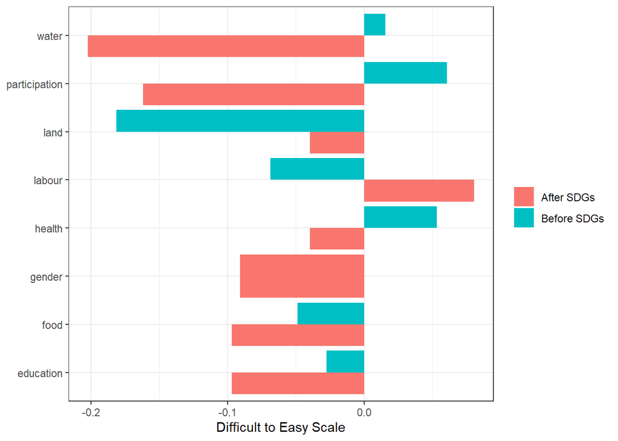

```r
glovePlot <-
ggplot(complex_sc, aes(x = word, y = value, fill = period)) +
  geom_col(position = "dodge") +
  coord_flip() +
  theme_bw() +
  labs(title = NULL, x = NULL, y = "Difficult to Easy Scale") +
  theme(legend.title=element_blank())
glovePlot
```

```r
#ggsave("glovePlot.jpeg")
```

- **Second attempt**

I thouhgt this better looking [cleaveland dot plot](https://www.r-graph-gallery.com/303-lollipop-plot-with-2-values.html) will be a more intuitive visaualisation.

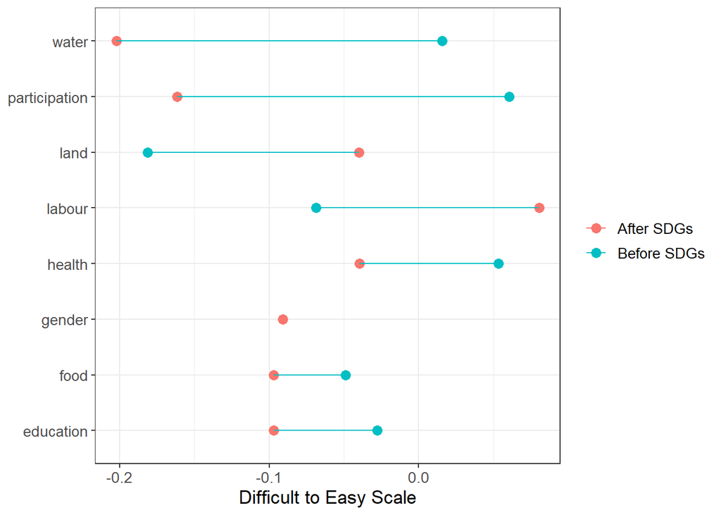

```r
ggplot(complex_sc, aes(x = word, y = value, col = period, group = word )) +
  geom_point(size = 3) +
  geom_line() +
  coord_flip() +
  #scale_colour_manual(values=c('black', 'lightgray')) +
  theme_bw() +
  labs(title = NULL, x = NULL, y = "Difficult to Easy Scale") +
  theme(legend.title=element_blank(),
        text = element_text(size=13))
```

```r
#ggsave("glovePlot3.jpeg")
```

The word embedding reveals that most of the selected SSI keywords were closer to after the SDGs, with water and participation having moved the closest to “Difficult”. The apparent increase in the use of selected SSI keywords after the SDGs (in the historical trend analysis) and the results of the word embedding model show that these topics (therefore the associated social sustainability indicators) appear to be progressively seen as more challenging in the literature and are of interest to researchers.

```r
paper_tokens_period %>%
                 filter(period == "Before SDGs") %>%
  filter(word == "gender")
```

| period | word | n |
| --- | --- | --- |
| Before SDGs | gender | 4 |

```r
# paper_tokens_period %>%
#  filter(word %in% c("social", "labour", "labour", "food", "health", "water", "participation", "land", "education", "gender"))
```

[output not shown]

[output not shown]

### The T-distributed Stochastic Neighbor Embedding

Training word embedding is an unsupervised machine learning process, and as such, there are no right answers to test the result [4]. Yet, validating the word embedding learned from our text collections is necessary before using them as the basis for a serious analysis. The T-distributed Stochastic Neighbor Embedding (t-SNE) algorithm represents words with high-dimensional vectors (100-D in our case) in a two-dimensional space [5] that can help to visually validate the model.

- **t-SNE before the SDGs**

```r
test_words <- c("sustainable", "Development", "agriculture", "rural", "sustainability")

set.seed(4005)

tsne_b <- Rtsne(before_word_vectors, perplexity = 45)
```

- **t-SNE after the SDGs**

```r
set.seed(4005)

tsne_a <- Rtsne(after_word_vectors, perplexity = 45)
```

```r
sample_b <-
tsne_b$Y  %>%
as.data.frame() %>%
mutate(word = row.names(before_word_vectors)) %>%
filter(word %in% test_words)
#filter(between(V1, 2.9, 4.12) & between(V2, -2, -1))

sample_b
```

| V1 | V2 | word |
| --- | --- | --- |
| -0.14746005 | -7.374119 | rural |
| -0.11122836 | -7.071084 | sustainable |
| 0.02525043 | -7.172560 | agriculture |
| -2.34724018 | -4.744177 | sustainability |

```r
# preparing the scale to be used in a graph bellow
 max_v1_b <- max(sample_b$V1) +1

 min_v1_b <- min(sample_b$V1) - 1

 max_v2_b <- max(sample_b$V2) + 1

 min_v2_b <- min(sample_b$V2) - 1
```

```r
sample_a <-
tsne_a$Y  %>%
as.data.frame() %>%
mutate(word = row.names(after_word_vectors)) %>%
filter(word %in% test_words)
#filter(between(V1, 2.9, 4.12) & between(V2, -2, -1))

sample_a
```

| V1 | V2 | word |
| --- | --- | --- |
| 4.630034 | -3.776960 | rural |
| -1.406836 | -7.673525 | agriculture |
| -1.595790 | -7.557773 | sustainable |
| 1.563114 | -6.685928 | sustainability |

```r
# preparing the scale to be used in a graph bellow
 max_v1_a <- max(sample_a$V1) +1

 min_v1_a <- min(sample_a$V1) -1

 max_v2_a <- max(sample_a$V2) +1

 min_v2_a <- min(sample_a$V2) -1
```

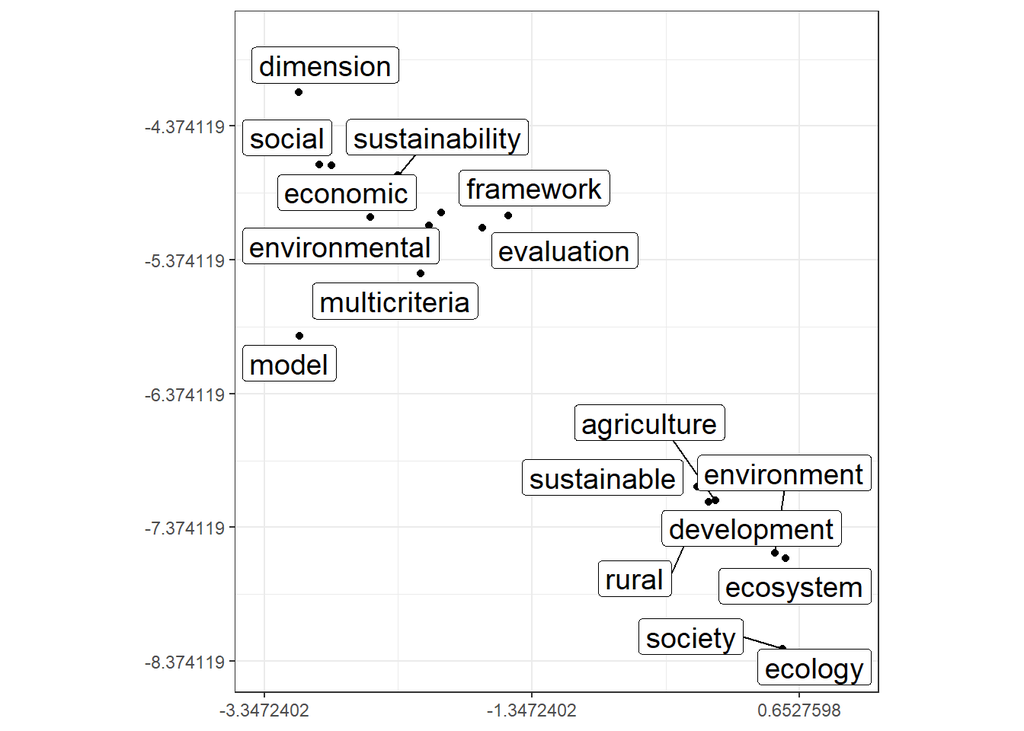

```r
word_label_b <- tsne_b$Y  %>%
                as.data.frame() %>%
                mutate(word = row.names(before_word_vectors)) %>%
                filter(word %in% c("evaluation", "framework",
                                    "sustainability", "assessment",
                                    "approach", "multicriteria",
                                    "framework", "model",
                                    "dimension", "economic",
                                    "social", "environmental",
                                    "sustainable",
                                    "agriculture", "rural",
                                    "development", "sustainable",
                                    "environment", "ecosystem",
                                     "ecology",
                                    "society",  "society"))


data_b <-  tsne_b$Y  %>%
  as.data.frame() %>%
  mutate(word = row.names(before_word_vectors))

tsne_plot_b <- data_b %>%
  ggplot(aes(x = V1, y = V2, label = word)) +
  #geom_text(size = 3) +
  geom_point(data = word_label_b) +
  geom_label_repel(data = word_label_b, size = 5, aes(label = word)) +
  scale_x_continuous(limits = c(min_v1_b, max_v1_b),
                     breaks = seq(min_v1_b, max_v1_b, by = 2))  +
    scale_y_continuous(limits = c(min_v2_b, max_v2_b),
                     breaks = seq(min_v2_b, max_v2_b, by = 1)) +
  labs(x = NULL, y = NULL) +
  theme( text = element_text(size=13)) +
                       coord_fixed() +
  theme_bw()
tsne_plot_b
```

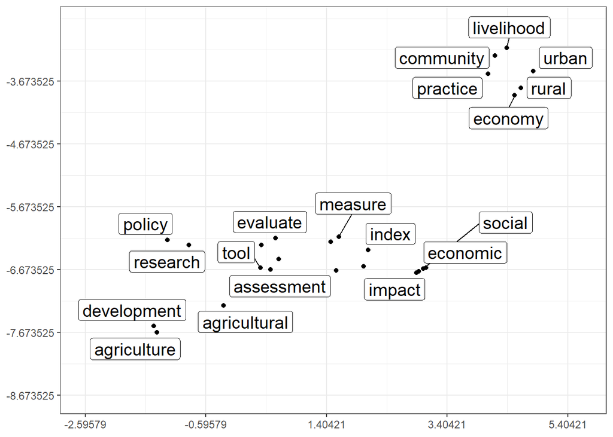

[output not shown]

```r
word_label_a <- tsne_a$Y  %>%
                as.data.frame() %>%
                mutate(word = row.names(after_word_vectors)) %>%
                filter(word %in% c("agriculture", "agricultural",
                                   "production", "research",
                                   "community", "livelihood",
                                   "policy", "rural", "economy",
                                   "practice", "urban", "policy",
                                   "research","tool",
                                   "development", "farmers",
                                   "rural", "indicator",
                                   "index", "methodology",
                                   "measure","assessment",
                                   "environmental", "economic",
                                   "social", "impact",
                                   "sustainability", "assess",
                                   "methodology", "evaluate",
                                   "indicator",
                                   "dimension", "tool"))

data_a <- tsne_a$Y  %>%
  as.data.frame() %>%
  mutate(word = row.names(after_word_vectors))

tsne_plot_a <- data_a %>%
#filter(between(V1, 6, 11.5) & between(V2, 16, 21)) %>%
  ggplot(aes(x = V1, y = V2, label = word)) +
  #geom_text(size = 3) +
  geom_point(data = word_label_a) +
  geom_label_repel(data = word_label_a, size = 5, aes(label = word)) +
  scale_x_continuous(limits = c(min_v1_a, max_v1_a),
                     breaks = seq(min_v1_a, max_v1_a, by = 2))  +
    scale_y_continuous(limits = c(min_v2_a, max_v2_a),
                     breaks = seq(min_v2_a, max_v2_a, by = 1)) +
  labs(x = NULL, y = NULL) +
  theme(text = element_text(size=20)) +
  #coord_fixed() +
  theme_bw()
tsne_plot_a
```

# Some findings from the content analysis

I synthesized all the indicators retrieved from the literature in an Excel workbook.Indicators are categorized according to the spatial scale, the agri-food system (context), and the level on the results chain of the Theory of Change (ToC). The spatial scale is simply the human geographic scale at which indicators are selected and analysed in each study. The agri-food system refers to the context of the production system in which the indicator is measured. The ToC levels (input, activities, output, outcome, impact) were used to give an overview of the chain relationship between the indicators, from those related to the inputs to the impact through the activities, outputs and outcomes.

I’ll import the Excel file in the following code chunk.

```r
#import indicators database

indicators <- read_excel("Indicators_DataBase.xlsx")

head(indicators)
```

| Source | Year | Country or Region of study | Domain | Label | Indicator | Scale | Toc | Context |
| --- | --- | --- | --- | --- | --- | --- | --- | --- |
| Hammond J. et al (2021) | 2021 | Ethiopia | Food Security | FoodAccess | Food insecurity of access | Farm | Outcome | Integrated and multi-systems |
| Fallah-Alipour S. et al (2018) | 2018 | Iran | Food Security | FoodAccess | Food insecurity of access | Farm | Outcome | Integrated and multi-systems |
| Allen et al. (2019) | 2019 | Conceptual | Food Security | FoodAccess | Food insecurity of access | Conceptual | Outcome | Food system |
| Mullender et al. (2020) | 2020 | Conceptual | Food Security | FoodAccess | Food insecurity of access | Conceptual | Outcome | Integrated and multi-systems |
| Chopin et al. (2017) | 2017 | Guadeloupe | Food Security | NutriNeeds | Nutrient needs / dietary diversity | Regional | Outcome | Integrated and multi-systems |
| Zurek et al. (2018) | 2018 | EU | Food Security | NutriNeeds | Nutrient needs / dietary diversity | Supra-regional | Outcome | Food system |

Have a look at the count of indicators’ apparition according to the above-mentioned three categories.

```r
#import indicators database

indicators %>% group_by(Scale) %>% count()
```

| Scale | n |
| --- | --- |
| Community/Local | 61 |
| Conceptual | 26 |
| Farm | 263 |
| Multi-scale | 11 |
| Regional | 33 |
| SLR | 9 |
| Supra-regional | 30 |

```r
indicators %>% group_by(Context) %>% count()
```

| Context | n |
| --- | --- |
| Aquaculture/Fisheries | 4 |
| Conceptual | 15 |
| Cropping systems | 95 |
| Food system | 53 |
| Forest/Plantation | 46 |
| Integrated and multi-systems | 172 |
| Livestock | 48 |

```r
indicators %>% group_by(Toc) %>% count()
```

| Toc | n |
| --- | --- |
| Activity | 220 |
| Impact | 58 |
| Input | 116 |
| Outcome | 17 |
| Output | 22 |

## Social sustainability indicators at different spatial scales

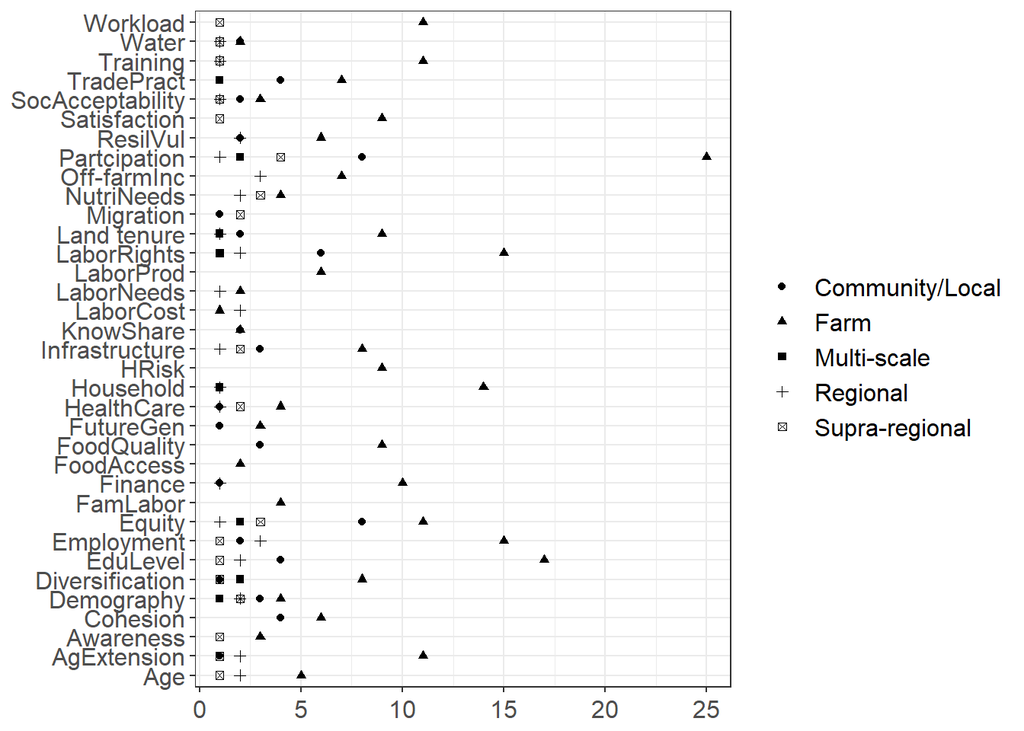

```r
plot_scale <-
indicators %>%
  filter(Scale %in% c("Farm", "Community/Local",
                      "Regional", "Supra-regional",
                      "Multi-scale")) %>%
  group_by(Label, Scale) %>%
  count() %>%
  ggplot(aes( x = Label, y = n, shape = Scale)) +
  geom_point() +
  theme_bw() +
  labs(title = NULL, x = NULL, y = NULL) +
  coord_flip() +
  theme(#legend.position = "none",
          plot.title=element_text(hjust=0.5),
          text = element_text(size=15),
          legend.title = element_blank(),
          axis.text.x =
            element_text(angle = 0, vjust = 0.5, hjust=0.5)) #+
  #geom_label_repel(aes(label = Label, fill = factor(Domain)),
                   #size = 4.5, fontface = "bold") +
  #coord_flip()

plot_scale
```

The occurrence of the indicators by spatial scale of analysis. Indicators are primarily used at the farm level (66%), followed by the community level (15%), the regional level (8%), the supra-regional level (8%), and studies using indicators at multiple scales (3%).

## Social sustainability indicators in different agri-food systems

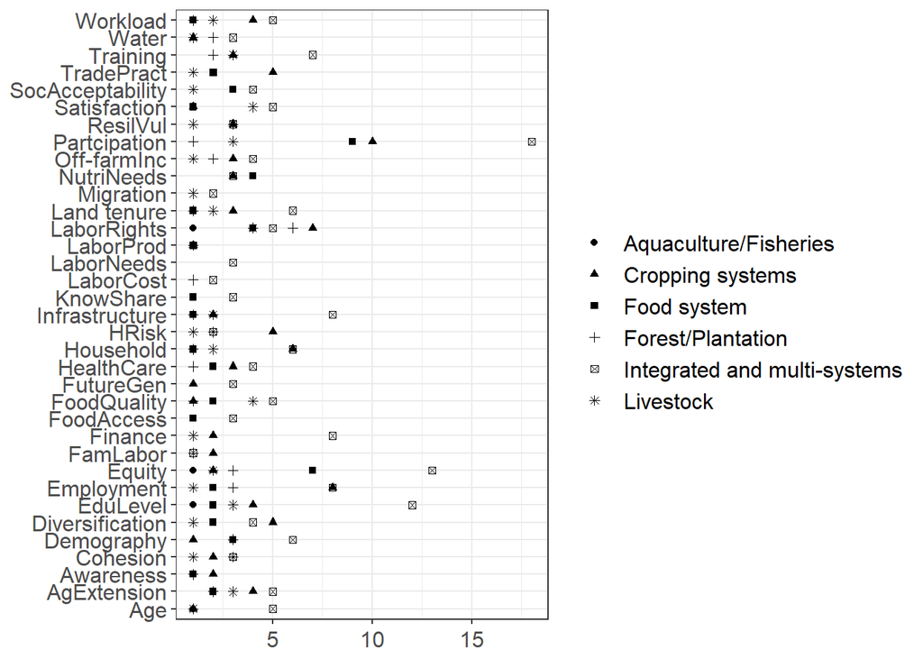

```r
plot_cont_3 <-
indicators %>%
  filter(Context != "Conceptual") %>%
  group_by(Label, Context) %>%
  count() %>%
  ggplot(aes( x = Label, y = n, shape = Context)) +
  geom_point() +
  theme_bw() +
  labs(title = NULL, x = NULL, y = NULL) +
  coord_flip() +
  theme(#legend.position = "none",
          plot.title=element_text(hjust=0.5),
          text = element_text(size=15),
          legend.title = element_blank(),
          axis.text.x =
            element_text(angle = 0, vjust = 0.5, hjust=0.5)) #+
  #geom_label_repel(aes(label = Label, fill = factor(Domain)),
                   #size = 4.5, fontface = "bold") +
  #coord_flip()

plot_cont_3
```

Studies on integrated or multi-systems have the highest occurrence of social sustainability indicators (41%), followed by studies dealing exclusively with cropping systems (23%), those on food systems (13%), livestock (11%), and on agroforestry/plantation (11%), aquaculture and fisheries (01%).

## Social sustainability indicators at different levels of the ToC

- **Data preparation**

```r
data <-
read_excel("Indicators_DataBase.xlsx", sheet = "Sheet2") %>%
  #filter(Context != "Conceptual") %>%
  group_by(Toc, Label) %>%
  count() %>%
  ungroup() %>%
  data.frame()


#data$Toc <- factor(data, levels = c("Input", "Activity", "Output",
            #"Outcome", "Impact") )


data <- data %>%
  mutate(Toc = factor(Toc, levels = c("Input", "Activity", "Output",
           "Outcome", "Impact"))) %>%
  arrange(Toc)

#levels(data$Toc)
#data

# Set a number of 'empty bar' to add at the end of each group
empty_bar <- 2
to_add <- data.frame( matrix(NA, empty_bar*nlevels(data$Toc), ncol(data)) )
colnames(to_add) <- colnames(data)
to_add$Toc <- rep(levels(data$Toc), each=empty_bar)

data <- rbind(data, to_add)
data <- data %>% arrange(Toc, n)
data$id <- seq(1, nrow(data))


# Get the name and the y position of each label
label_data <- data
number_of_bar <- nrow(label_data)
angle <- 90 - 360 * (label_data$id-0.5) /number_of_bar     # I substract 0.5 because the letter must have the angle of the center of the bars. Not extreme right(1) or extreme left (0)
label_data$hjust <- ifelse( angle < -90, 1, 0)
label_data$angle <- ifelse(angle < -90, angle+180, angle)

# prepare a data frame for base lines
base_data <- data %>%
  group_by(Toc) %>%
  summarize(start=min(id), end=max(id) - empty_bar) %>%
  rowwise() %>%
  mutate(title=mean(c(start, end)))

# prepare a data frame for grid (scales)
grid_data <- base_data
grid_data$end <- grid_data$end[ c(nrow(grid_data), 1:nrow(grid_data)-1)] + 1
grid_data$start <- grid_data$start - 1
grid_data <- grid_data[-1,]
```

- **Circular bar plot**

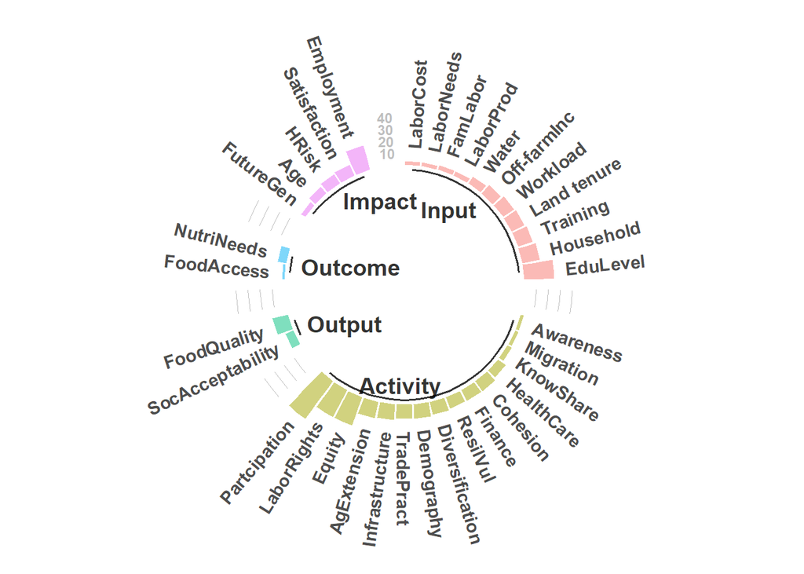

```r
# Make the plot
p <- data %>%

  ggplot(aes(x=as.factor(id), y=n, fill = Toc)) +       # Note that id is a factor. If x is numeric, there is some space between the first bar

  geom_bar(aes(x=as.factor(id), y=n, fill= Toc), stat="identity", alpha=0.5) +

  # Add a val=40/30/20/10 lines. I do it at the beginning to make sure barplots are OVER it.
  geom_segment(data=grid_data, aes(x = end, y = 40, xend = start, yend = 40), colour = "grey", alpha=1, size=0.3 , inherit.aes = FALSE ) +
  geom_segment(data=grid_data, aes(x = end, y = 30, xend = start, yend = 30), colour = "grey", alpha=1, size=0.3 , inherit.aes = FALSE ) +
  geom_segment(data=grid_data, aes(x = end, y = 20, xend = start, yend = 20), colour = "grey", alpha=1, size=0.3 , inherit.aes = FALSE ) +
  geom_segment(data=grid_data, aes(x = end, y = 10, xend = start, yend = 10), colour = "grey", alpha=1, size=0.3 , inherit.aes = FALSE ) +

  # Add text showing the value of each 40/30/20/10 lines
  ggplot2::annotate("text", x = rep(max(data$id),4), y = c(10, 20, 30, 40), label = c("10", "20", "30", "40") , color="grey", size=3 , angle=0, fontface="bold", hjust=1) +

  #geom_bar(aes(x=as.factor(id), y=n, fill=Toc), stat="identity", alpha=0.5) +
  ylim(-100,120) +
  theme_minimal() +
  theme(
    legend.position = "none",
    axis.text = element_blank(),
    axis.title = element_blank(),
    panel.grid = element_blank(),
    plot.margin = unit(rep(-1,4), "cm")
  ) +
  coord_polar() +
  geom_text(data=label_data, aes(x=as.factor(id), y=n+10, label=Label, hjust=hjust), color="black", fontface="bold",alpha=0.7, size=4, angle= label_data$angle, inherit.aes = FALSE ) +

  # Add base line information
  geom_segment(data=base_data, aes(x = start, y = -4, xend = end, yend = -4), colour = "black", alpha=0.8, size=0.6 , inherit.aes = FALSE )  +
  geom_text(data=base_data, aes(x = title, y = -13, label=Toc),hjust=c(1,0.9,0,0,0), colour = "black", alpha=0.8, size=5, fontface="bold", inherit.aes = FALSE)

p
```

The figure shows that most indicators are activity-related (51%), followed by the input level (27%), impact indicators (13%), output level indicators (05%), and outcome level indicators (04%).

For more on the interpretation of all the results, check out the paper. I will add the link to my publication list once it is published.

# References

[1]

J. Endrikat, “Market Reactions to Corporate Environmental Performance Related Events: A Meta-analytic Consolidation of the Empirical Evidence,” *Journal of Business Ethics*, vol. 138, no. 3, pp. 535–548, Oct. 2016, doi: 10.1007/s10551-015-2598-0. [Online]. Available: https://doi.org/10.1007/s10551-015-2598-0. [Accessed: 15-Nov-2022]

[2]

E. Hvitfeldt and J. Silge, *Supervised Machine Learning for Text Analysis in R*. New York: Chapman; Hall/CRC, 2021 [Online]. Available: https://doi.org/10.1201/9781003093459

[3]

J. R. Firth, *Papers in linguistics, 1934-1951.* London; New York: Oxford University Press, 1957 [Online]. Available: https://doi.org/10.1017/S0041977X00060559

[4]

K. Lee, J. Braithwaite, and M. Atchikpa, “Understanding Colonial Legacy and Environmental Issues in Senegal Through Language Use,” in *Social, Cultural, and Behavioral Modeling*, 2020, pp. 23–34, doi: 10.1007/978-3-030-61255-9_3.

[5]

L. van der Maaten and G. Hinton, “Visualizing Data using t-SNE,” *Journal of Machine Learning Research*, vol. 9, no. 86, pp. 2579–2605, 2008 [Online]. Available: http://jmlr.org/papers/v9/vandermaaten08a.html. [Accessed: 12-Apr-2022]